# Стратегия взаимодействия с клиентами на основе аналитических данных

# Содержание

## Описание проекта

В данном исследовании проводится разработка стратегии взаимодействия с клиентами фитнес-центров на основе аналитических данных.

**Основные задачи**:

- провести анализ данных анкет клиентов фитнес-центров
- подготовить план действий по удержанию клиентов

**План работы**:

- научиться прогнозировать вероятность оттока (на уровне следующего месяца) для каждого клиента
- сформировать типичные портреты клиентов
- проанализировать основные признаки, наиболее сильно влияющие на отток
- сформулировать основные выводы и разработать рекомендации по повышению качества работы с клиентами

**Описание данных**:

В исследовании используются данные из клиентских анкет, собранные и переведённые в электронный вид сотрудниками отдела по работе с клиентами.

## Открытие данных

Импортируем необходимые библиотеки:

```python
import pandas as pd
import os

from matplotlib import pyplot as plt
import matplotlib.gridspec as gridspec
import seaborn as sns
import numpy as np

from sklearn.preprocessing import StandardScaler
from sklearn.model_selection import train_test_split
from sklearn.linear_model import LogisticRegression
from sklearn.ensemble import RandomForestClassifier
from sklearn.metrics import accuracy_score, precision_score, recall_score
from scipy.cluster import hierarchy
from scipy.cluster.hierarchy import dendrogram, linkage
from sklearn.cluster import KMeans

import warnings
```

```python
warnings.filterwarnings("ignore")
```

Открываем файл:

```python
if os.path.exists('/datasets/gym_churn.csv'):
    df = pd.read_csv('/datasets/gym_churn.csv')
else:
    df = pd.read_csv('/C:/datasets/gym_churn.csv')
```

Для ознакомления и проверки данных будем использовать собственную функцию:

```python
def my_check_function (dataset):
    '''Функция для ознакомления и проверки даных'''
    print('Размер датасета (количество строк, столбцов):')
    print(dataset.shape)
    print('Как выглядят случайные 5 строк:')
    display(dataset.sample(5, random_state=42))
    print()
    print('Общая информация о данных, наименования столбцов, типы данных:')
    print(dataset.info())
    print()
    print('Есть ли пропуски, сколько их:')
    print(dataset.isna().sum())
    print('Доля пропущенных значений:')
    print(dataset.isna().mean())
    print()
    print('Есть ли явные дубликаты, сколько их:')
    print(dataset.duplicated().sum())
    print('Доля явных дубликатов:')
    print(dataset.duplicated().mean())
    print()
    print('Подробное описание данных:')
    display(dataset.describe())
```

```python
my_check_function(df)
```

```
Размер датасета (количество строк, столбцов):
(4000, 14)
Как выглядят случайные 5 строк:
```

|  | gender | Near_Location | Partner | Promo_friends | Phone | Contract_period | Group_visits | Age | Avg_additional_charges_total | Month_to_end_contract | Lifetime | Avg_class_frequency_total | Avg_class_frequency_current_month | Churn |
| --- | --- | --- | --- | --- | --- | --- | --- | --- | --- | --- | --- | --- | --- | --- |
| 555 | 1 | 1 | 0 | 0 | 1 | 6 | 1 | 37 | 205.631751 | 5.0 | 2 | 1.400690 | 1.614663 | 0 |
| 3491 | 0 | 0 | 0 | 0 | 1 | 6 | 0 | 27 | 137.370917 | 6.0 | 24 | 0.918920 | 1.093414 | 0 |
| 527 | 1 | 1 | 0 | 0 | 1 | 1 | 1 | 25 | 41.607768 | 1.0 | 1 | 2.893104 | 2.813602 | 0 |
| 3925 | 1 | 0 | 0 | 0 | 1 | 1 | 0 | 31 | 9.593524 | 1.0 | 14 | 2.131718 | 2.147013 | 0 |
| 2989 | 1 | 1 | 0 | 0 | 0 | 1 | 0 | 30 | 275.271537 | 1.0 | 4 | 1.653789 | 1.738444 | 0 |

```
Общая информация о данных, наименования столбцов, типы данных:
<class 'pandas.core.frame.DataFrame'>
RangeIndex: 4000 entries, 0 to 3999
Data columns (total 14 columns):
 #   Column                             Non-Null Count  Dtype
---  ------                             --------------  -----
 0   gender                             4000 non-null   int64
 1   Near_Location                      4000 non-null   int64
 2   Partner                            4000 non-null   int64
 3   Promo_friends                      4000 non-null   int64
 4   Phone                              4000 non-null   int64
 5   Contract_period                    4000 non-null   int64
 6   Group_visits                       4000 non-null   int64
 7   Age                                4000 non-null   int64
 8   Avg_additional_charges_total       4000 non-null   float64
 9   Month_to_end_contract              4000 non-null   float64
 10  Lifetime                           4000 non-null   int64
 11  Avg_class_frequency_total          4000 non-null   float64
 12  Avg_class_frequency_current_month  4000 non-null   float64
 13  Churn                              4000 non-null   int64
dtypes: float64(4), int64(10)
memory usage: 437.6 KB
None

Есть ли пропуски, сколько их:
gender                               0
Near_Location                        0
Partner                              0
Promo_friends                        0
Phone                                0
Contract_period                      0
Group_visits                         0
Age                                  0
Avg_additional_charges_total         0
Month_to_end_contract                0
Lifetime                             0
Avg_class_frequency_total            0
Avg_class_frequency_current_month    0
Churn                                0
dtype: int64
```

[output cut: 8 more lines]

```
Age                                  0.0
Avg_additional_charges_total         0.0
Month_to_end_contract                0.0
Lifetime                             0.0
Avg_class_frequency_total            0.0
Avg_class_frequency_current_month    0.0
Churn                                0.0
dtype: float64

Есть ли явные дубликаты, сколько их:
0
Доля явных дубликатов:
0.0

Подробное описание данных:
```

|  | gender | Near_Location | Partner | Promo_friends | Phone | Contract_period | Group_visits | Age | Avg_additional_charges_total | Month_to_end_contract | Lifetime | Avg_class_frequency_total | Avg_class_frequency_current_month | Churn |
| --- | --- | --- | --- | --- | --- | --- | --- | --- | --- | --- | --- | --- | --- | --- |
| count | 4000.000000 | 4000.000000 | 4000.000000 | 4000.000000 | 4000.000000 | 4000.000000 | 4000.000000 | 4000.000000 | 4000.000000 | 4000.000000 | 4000.000000 | 4000.000000 | 4000.000000 | 4000.000000 |
| mean | 0.510250 | 0.845250 | 0.486750 | 0.308500 | 0.903500 | 4.681250 | 0.412250 | 29.184250 | 146.943728 | 4.322750 | 3.724750 | 1.879020 | 1.767052 | 0.265250 |
| std | 0.499957 | 0.361711 | 0.499887 | 0.461932 | 0.295313 | 4.549706 | 0.492301 | 3.258367 | 96.355602 | 4.191297 | 3.749267 | 0.972245 | 1.052906 | 0.441521 |
| min | 0.000000 | 0.000000 | 0.000000 | 0.000000 | 0.000000 | 1.000000 | 0.000000 | 18.000000 | 0.148205 | 1.000000 | 0.000000 | 0.000000 | 0.000000 | 0.000000 |
| 25% | 0.000000 | 1.000000 | 0.000000 | 0.000000 | 1.000000 | 1.000000 | 0.000000 | 27.000000 | 68.868830 | 1.000000 | 1.000000 | 1.180875 | 0.963003 | 0.000000 |
| 50% | 1.000000 | 1.000000 | 0.000000 | 0.000000 | 1.000000 | 1.000000 | 0.000000 | 29.000000 | 136.220159 | 1.000000 | 3.000000 | 1.832768 | 1.719574 | 0.000000 |
| 75% | 1.000000 | 1.000000 | 1.000000 | 1.000000 | 1.000000 | 6.000000 | 1.000000 | 31.000000 | 210.949625 | 6.000000 | 5.000000 | 2.536078 | 2.510336 | 1.000000 |
| max | 1.000000 | 1.000000 | 1.000000 | 1.000000 | 1.000000 | 12.000000 | 1.000000 | 41.000000 | 552.590740 | 12.000000 | 31.000000 | 6.023668 | 6.146783 | 1.000000 |

**Вывод**:

На первый взгляд, перед нами хорошо подготовленные данные: нет никаких пропусков, все данные уже в числовых форматах. Размер данных кажется достаточным для исследования: 4000 строк и 14 столбцов.

Теперь взглянем подробнее на каждый столбец и посмотрим, что данные могут сообщить нам на первоначальном этапе:

**Пол**: популярность фитнес-центров примерно одинакова и среди мужчин, и среди женщин (с незначительным перевесом в сторону мужчин)

**Район**: очень часто клиентами становятся люди, которые живут или работают недалеко от фитнес-центров

**Партнёрство**: почти половина клиентов - сотрудники компаний-партнёров клуба. Но всё же небольшой перевес на стороне клиентов, не связанных с партнёрской программой

**Приведи друга**: не очень много людей использовали промокод от знакомого или друга при оплате первого абонемента

**Телефон**: большинство клиентов оставляют свой номер телефона

**Длительность текущего абонемента**: у нас есть абонементы на 1, 6, 12 месяцев, а в среднем мы имеем 4/5 месяцев

**Групповые занятия**: около 40% клиентов посещают групповые занятия

**Возраст**: средний возраст клиентов 29 лет, разброс стандартное отклонение небольшое, максимальный возраст 41 год

**Суммарная выручка от других услуг**: вот здесь мы наблюдаем уже бОльшее разнообразие: при среднем 146 стандартное отклонение 96. Кажется, клиенты ведут себя по-разному: кто-то практически не пользуется дополнительными услугами

**Срок до окончания абонемента**: цифры чуть меньше, чем длительность текущего абонемента, но в целом очень похожи. Возможно, это говорит о том, что у нас много клиентов, которые недавно приобрели свои абонементы

**Лайфтайм**: среднее и стандартное отклонение говорят о том, что в целом у нас не так много "долгожителей" (а ведь это то, что мы хотим увеличить - наша цель удерживать клиентов подольше). В среднем клиент продерживается в фитнес-центре около 4 месяцев.

**Средняя частота посещеий в неделю**: судя по среднему и стандартному отклонению, большинство клиентов посещают фитнес-центры 2 раза в неделю

**Средняя частота посещений в неделю за предыдущий месяц**: мы видим сопоставимые цифры, но с чуть меньшим средним и с немного увеличенным стандартным отклонением. Предположу, что мы видим некоторый отток клиентов "в прямом эфире"

**Отток в текущем месяце**: большинство клиентов осталось с нами в текущий месяц, но наша цель - сократить отток, насколько это возможно. На данный момент 26.5% клиентов ушло в текущем месяце.

```python
df.columns = [x.lower() for x in df.columns]
```

### Вывод

У нас есть хорошо подготовленные данные: нет пропусков, все данные в числовых форматах. На первый взгляд не обнаружено аномалий или иных подозрительных данных.

Для удобства дальнейшей работы произведено только одно небольшое изменение: все названия столбцов приведены к единому нижнему регистру.

Благодаря первоначальному знакомству с данными мы уже имеем некоторое представление об имеющихся признаках и клиентах фитнес-центров. Продолжим далее это знакомство более детальным образом.

## Исследовательский анализ данных (EDA)

### Разделение клиентов на оставшихся и ушедших

Разделим наши данные на две группы - на тех, кто ушёл в отток в текущем месяце, и тех, кто остался:

```python
stay = df.query('churn == 0')
```

```python
leave = df.query('churn == 1')
```

Посмотрим, сколько именно человек осталось и ушло:

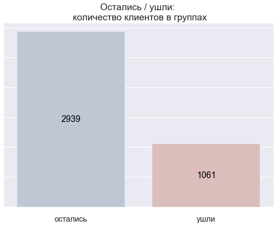

```python
plt.figure(figsize=(10, 7))
sns.set(font_scale=1.5)
plt.style.use('seaborn-poster')

ax=sns.barplot(x=['остались', 'ушли'], y=[len(stay),len(leave)], palette = 'vlag')
plt.title('Остались / ушли: \n количество клиентов в группах')
plt.xlabel('')
plt.ylabel('')

ax.set(yticklabels=[])
ax.tick_params(left=False)
ax.bar_label(ax.containers[0], label_type='center', color='black')
plt.show();
```

### Средние значения признаков в двух группах

Сделаем расчёты средних значений по каждой группе и отсортируем признаки от наименьшей к наибольшей разнице между группами:

```python
table = df.pivot_table(index='churn', values=df.columns, aggfunc='mean').T.reset_index().rename_axis(None, axis=1)
table.columns = ['features', 'stay_mean', 'leave_mean']
table['coef'] = table['leave_mean'] / table['stay_mean']
table = table.sort_values(by='coef', ascending=False).reset_index(drop=True)
table
```

|  | features | stay_mean | leave_mean | coef |
| --- | --- | --- | --- | --- |
| 0 | gender | 0.510037 | 0.510839 | 1.001571 |
| 1 | phone | 0.903709 | 0.902922 | 0.999129 |
| 2 | age | 29.976523 | 26.989632 | 0.900359 |
| 3 | near_location | 0.873086 | 0.768143 | 0.879802 |
| 4 | avg_class_frequency_total | 2.024876 | 1.474995 | 0.728437 |
| 5 | avg_additional_charges_total | 158.445715 | 115.082899 | 0.726324 |
| 6 | partner | 0.534195 | 0.355325 | 0.665160 |
| 7 | group_visits | 0.464103 | 0.268615 | 0.578782 |
| 8 | promo_friends | 0.353522 | 0.183789 | 0.519880 |
| 9 | avg_class_frequency_current_month | 2.027882 | 1.044546 | 0.515092 |
| 10 | month_to_end_contract | 5.283089 | 1.662582 | 0.314699 |
| 11 | contract_period | 5.747193 | 1.728558 | 0.300766 |
| 12 | lifetime | 4.711807 | 0.990575 | 0.210233 |

Округлим результаты до двух знаков после запятой:

```python
table['stay_mean'] = table['stay_mean'].round(2)
table['leave_mean'] = table['leave_mean'].round(2)
```

Для наглядности и удобства сравнения построим ряд графиков:

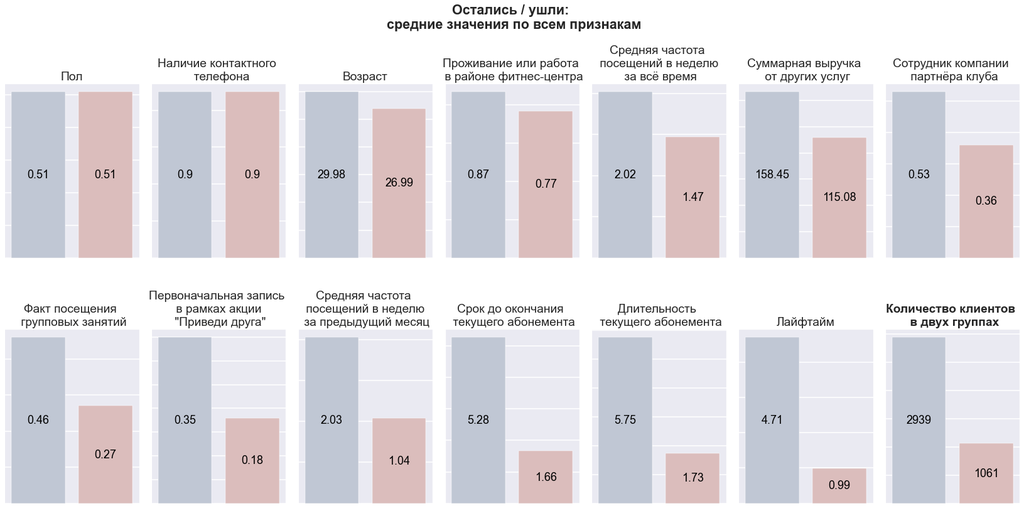

```python
plt.figure(figsize=(23, 12))
sns.set(font_scale=1.5)
plt.style.use('seaborn-poster')
plt.suptitle('Остались / ушли: \n средние значения по всем признакам', fontweight='bold')

ax1 = plt.subplot(2, 7, 1)
sns.barplot(data= table.iloc[0], x=['  ', ' '], y=['stay_mean', 'leave_mean'], palette = 'vlag')
plt.title('Пол')
plt.xlabel('')
plt.ylabel('')
ax1.set(yticklabels=[])
ax1.tick_params(left=False)
ax1.bar_label(ax1.containers[0], label_type='center', color='black')

ax2 = plt.subplot(2, 7, 2)
sns.barplot(data= table.iloc[1], x=['  ', ' '], y=['stay_mean', 'leave_mean'], palette = 'vlag')
plt.title('Наличие контактного \n  телефона')
plt.xlabel('')
plt.ylabel('')
ax2.set(yticklabels=[])
ax2.tick_params(left=False)
ax2.bar_label(ax2.containers[0], label_type='center', color='black')

ax3 = plt.subplot(2, 7, 3)
sns.barplot(data= table.iloc[2], x=['  ', ' '], y=['stay_mean', 'leave_mean'], palette = 'vlag')
plt.title('Возраст')
plt.xlabel('')
plt.ylabel('')
ax3.set(yticklabels=[])
ax3.tick_params(left=False)
ax3.bar_label(ax3.containers[0], label_type='center', color='black')

ax4 = plt.subplot(2, 7, 4)
sns.barplot(data= table.iloc[3], x=['  ', ' '], y=['stay_mean', 'leave_mean'], palette = 'vlag')
plt.title('Проживание или работа \n в районе фитнес-центра')
plt.xlabel('')
plt.ylabel('')
ax4.set(yticklabels=[])
ax4.tick_params(left=False)
ax4.bar_label(ax4.containers[0], label_type='center', color='black')

ax5 = plt.subplot(2, 7, 5)
sns.barplot(data= table.iloc[4], x=['  ', ' '], y=['stay_mean', 'leave_mean'], palette = 'vlag')
plt.title('Средняя частота \n посещений в неделю \n за всё время')
plt.xlabel('')
plt.ylabel('')
ax5.set(yticklabels=[])
ax5.tick_params(left=False)
ax5.bar_label(ax5.containers[0], label_type='center', color='black')

ax6 = plt.subplot(2, 7, 6)
sns.barplot(data= table.iloc[5], x=['  ', ' '], y=['stay_mean', 'leave_mean'], palette = 'vlag')
plt.title('Суммарная выручка \n от других услуг')
plt.xlabel('')
plt.ylabel('')
ax6.set(yticklabels=[])
ax6.tick_params(left=False)
ax6.bar_label(ax6.containers[0], label_type='center', color='black')

ax7 = plt.subplot(2, 7, 7)
sns.barplot(data= table.iloc[6], x=['  ', ' '], y=['stay_mean', 'leave_mean'], palette = 'vlag')
plt.title('Сотрудник компании \n партнёра клуба')
plt.xlabel('')
plt.ylabel('')
ax7.set(yticklabels=[])
ax7.tick_params(left=False)
ax7.bar_label(ax7.containers[0], label_type='center', color='black')

ax8 = plt.subplot(2, 7, 8)
sns.barplot(data= table.iloc[7], x=['  ', ' '], y=['stay_mean', 'leave_mean'], palette = 'vlag')
plt.title('Факт посещения \n групповых занятий')
plt.xlabel('')
plt.ylabel('')
ax8.set(yticklabels=[])
ax8.tick_params(left=False)
ax8.bar_label(ax8.containers[0], label_type='center', color='black')

ax9 = plt.subplot(2, 7, 9)
sns.barplot(data= table.iloc[8], x=['  ', ' '], y=['stay_mean', 'leave_mean'], palette = 'vlag')
plt.title('Первоначальная запись \n в рамках акции \n "Приведи друга"')
plt.xlabel('')
plt.ylabel('')
ax9.set(yticklabels=[])
ax9.tick_params(left=False)
ax9.bar_label(ax9.containers[0], label_type='center', color='black')

ax10 = plt.subplot(2, 7, 10)
sns.barplot(data= table.iloc[9], x=['  ', ' '], y=['stay_mean', 'leave_mean'], palette = 'vlag')
plt.title('Средняя частота \n посещений в неделю \n за предыдущий месяц')
plt.xlabel('')
plt.ylabel('')
ax10.set(yticklabels=[])
ax10.tick_params(left=False)
ax10.bar_label(ax10.containers[0], label_type='center', color='black')

ax11 = plt.subplot(2, 7, 11)
sns.barplot(data= table.iloc[10], x=['  ', ' '], y=['stay_mean', 'leave_mean'], palette = 'vlag')
plt.title('Срок до окончания \n текущего абонемента')
plt.xlabel('')
plt.ylabel('')
ax11.set(yticklabels=[])
ax11.tick_params(left=False)
ax11.bar_label(ax11.containers[0], label_type='center', color='black')

ax12 = plt.subplot(2, 7, 12)
sns.barplot(data= table.iloc[11], x=['  ', ' '], y=['stay_mean', 'leave_mean'], palette = 'vlag')
plt.title('Длительность \n текущего абонемента')
plt.xlabel('')
plt.ylabel('')
ax12.set(yticklabels=[])
ax12.tick_params(left=False)
ax12.bar_label(ax12.containers[0], label_type='center', color='black')

ax13 = plt.subplot(2, 7, 13)
sns.barplot(data= table.iloc[12], x=['  ', ' '], y=['stay_mean', 'leave_mean'], palette = 'vlag')
plt.title('Лайфтайм')
plt.xlabel('')
plt.ylabel('')
ax13.set(yticklabels=[])
ax13.tick_params(left=False)
ax13.bar_label(ax13.containers[0], label_type='center', color='black')

ax14 = plt.subplot(2, 7, 14)
sns.barplot(x=['  ', ' '], y=[len(stay),len(leave)], palette = 'vlag')
plt.title('Количество клиентов \n в двух группах', fontweight='bold')
plt.xlabel('')
plt.ylabel('')
ax14.set(yticklabels=[])
ax14.tick_params(left=False)
ax14.bar_label(ax14.containers[0], label_type='center', color='black')

plt.tight_layout()
plt.show();
```

**Вывод**:

Как мы видим, есть признаки, у которых средние значения двух групп находятся **на одном уровне**:

- пол
- наличие контактного телефона

И ушедшие, и оставшиеся клиенты - люди обоих полов, и все они охотно оставляют свои номера телефонов.

Признаки, средние значения которых в двух группах **отличаются незначительно**:

- проживание или работа в районе фитнес-центра
- возраст

Ушедшие клиенты не так часто проживали или работали в районе фитнес-центров (по сравнению с оставшимися). Ушедшие клиенты в среднем чуть моложе: 27 лет против 30 у оставшихся.

В остальных признаках мы видим заметные отличия клиентов. **Отличаются менее чем в 2 раза** средние показатели следующих признаков:

- средняя частота посещений в неделю за всё время
- суммарная выручка от других услуг
- сотрудник компании-партнёра клуба

Ушедшие клиенты реже появлялись в заведениях сети, для них характерна более низкая суммарная выручка от других услуг фитнес-центров, и они реже являлись сотрудниками компании-партнёра клуба.

**Отличаются значительно**(примерно в 2 раза и более) средние значения признаков:

- факт посещения групповых занятий
- первоначальная запись в рамках акции "Приведи друга"
- средняя частота посещений в неделю за предыдущий месяц
- срок до окончания текущего абонемента
- длительность текущего абонемента
- лайфтайм

Ушедшие пользователи реже посещали групповые занятия, реже получали и использовали промокод от знакомых и друзей. Ушедшие клиенты и реже посещали зал (в среднем 1 раз в неделю) перед моментом своего "ухода". Такие пользователи имели небольшой срок до его окончания абонемента (около 1.5 месяцев) и в основном приобретали абонементы с небольшой длительностью (в среднем всего около 1.5-2 месяцев). Ушедшие в отток ненадолго задержались в статусе клиентов - средний лайфтайм ушедших чуть меньше 1 месяца.

### Столбчатые гистограммы и распределения признаков для двух групп

Для удобства чтения графиков сделаем копию наших данных, где изменим цифры 0 и 1 на слова:

```python
df_words = df
df_words = df_words.replace({'near_location': {0:'нет', 1:'да'},
                            'partner': {0:'нет', 1:'да'},
                            'promo_friends': {0:'нет', 1:'да'},
                            'phone': {0:'нет', 1:'да'},
                            'group_visits': {0:'нет', 1:'да'},
                            'gender':{0:'женщины', 1:'мужчины'},
                            'churn':{0:'остались', 1:'ушли'}})
df_words.head()
```

|  | gender | near_location | partner | promo_friends | phone | contract_period | group_visits | age | avg_additional_charges_total | month_to_end_contract | lifetime | avg_class_frequency_total | avg_class_frequency_current_month | churn |
| --- | --- | --- | --- | --- | --- | --- | --- | --- | --- | --- | --- | --- | --- | --- |
| 0 | мужчины | да | да | да | нет | 6 | да | 29 | 14.227470 | 5.0 | 3 | 0.020398 | 0.000000 | остались |
| 1 | женщины | да | нет | нет | да | 12 | да | 31 | 113.202938 | 12.0 | 7 | 1.922936 | 1.910244 | остались |
| 2 | женщины | да | да | нет | да | 1 | нет | 28 | 129.448479 | 1.0 | 2 | 1.859098 | 1.736502 | остались |
| 3 | женщины | да | да | да | да | 12 | да | 33 | 62.669863 | 12.0 | 2 | 3.205633 | 3.357215 | остались |
| 4 | мужчины | да | да | да | да | 1 | нет | 26 | 198.362265 | 1.0 | 3 | 1.113884 | 1.120078 | остались |

Построим графики распределения признаков:

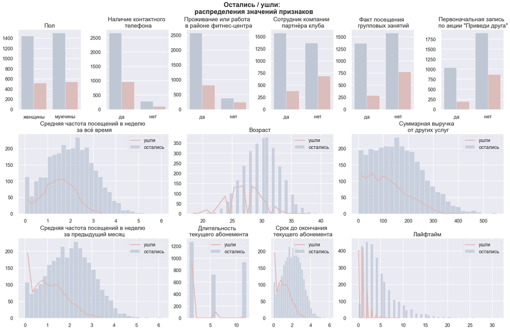

```python
fig = plt.figure(constrained_layout=True, figsize=(23, 15))
sns.set(font_scale=1.5)
plt.style.use('seaborn-poster')
plt.suptitle('Остались / ушли: \n распределения значений признаков', fontweight='bold')

spec = gridspec.GridSpec(ncols=6, nrows=3, figure=fig)

ax0 = fig.add_subplot(spec[0, 0])
data = df_words.groupby(['churn', 'gender'], as_index=False).agg({'phone':'count'})
sns.barplot(data=data, x='gender', y='phone', hue ='churn', palette = 'vlag')
plt.title('Пол')
plt.xlabel('')
plt.ylabel('')
ax0.get_legend().remove()

ax1 = fig.add_subplot(spec[0, 1])
data = df_words.groupby(['churn', 'phone'], as_index=False).agg({'gender':'count'})
sns.barplot(data=data, x='phone', y='gender', hue ='churn', palette = 'vlag')
plt.title('Наличие контактного \n телефона')
plt.xlabel('')
plt.ylabel('')
ax1.get_legend().remove()

ax2 = fig.add_subplot(spec[0, 2])
data = df_words.groupby(['churn', 'near_location'], as_index=False).agg({'phone':'count'})
sns.barplot(data=data, x='near_location', y='phone', hue ='churn', palette = 'vlag')
plt.title('Проживание или работа \n в районе фитнес-центра')
plt.xlabel('')
plt.ylabel('')
ax2.get_legend().remove()

ax3 = fig.add_subplot(spec[0, 3])
data = df_words.groupby(['churn', 'partner'], as_index=False).agg({'phone':'count'})
sns.barplot(data=data, x='partner', y='phone', hue ='churn', palette = 'vlag')
plt.title('Сотрудник компании \n партнёра клуба')
plt.xlabel('')
plt.ylabel('')
ax3.get_legend().remove()

ax4 = fig.add_subplot(spec[0, 4])
data = df_words.groupby(['churn', 'group_visits'], as_index=False).agg({'phone':'count'})
sns.barplot(data=data, x='group_visits', y='phone', hue ='churn', palette = 'vlag')
plt.title('Факт посещения \n групповых занятий')
plt.xlabel('')
plt.ylabel('')
ax4.get_legend().remove()

ax5 = fig.add_subplot(spec[0, 5])
data = df_words.groupby(['churn', 'promo_friends'], as_index=False).agg({'phone':'count'})
sns.barplot(data=data, x='promo_friends', y='phone', hue ='churn', palette = 'vlag')
plt.title('Первоначальная запись \n по акции "Приведи друга"')
plt.xlabel('')
plt.ylabel('')
ax5.get_legend().remove()

ax6 = fig.add_subplot(spec[1, :-4])
sns.histplot(data=stay, x='avg_class_frequency_total',  color='#bdc6d7', label='остались')
sns.histplot(data=leave, x='avg_class_frequency_total',  color='#e1b9b6', element="poly", fill=False, linewidth=3,
             label='ушли')
plt.title('Средняя частота посещений в неделю \n за всё время')
plt.xlabel('')
plt.ylabel('')
plt.legend()

ax7 = fig.add_subplot(spec[1, -4:-2])
sns.histplot(data=stay, x='age',  color='#bdc6d7', label='остались')
sns.histplot(data=leave, x='age',  color='#e1b9b6', element="poly", fill=False, linewidth=3, label='ушли')
plt.title('Возраст')
plt.xlabel('')
plt.ylabel('')
plt.legend()

ax8 = fig.add_subplot(spec[1, -2:])
sns.histplot(data=stay, x='avg_additional_charges_total',  color='#bdc6d7', label='остались')
sns.histplot(data=leave, x='avg_additional_charges_total',  color='#e1b9b6', element="poly", fill=False, linewidth=3,
            label='ушли')
plt.title('Суммарная выручка \n от других услуг')
plt.xlabel('')
plt.ylabel('')
plt.legend()

ax9 = fig.add_subplot(spec[2, :-4])
sns.histplot(data=stay, x='avg_class_frequency_current_month',  color='#bdc6d7', label='остались')
sns.histplot(data=leave, x='avg_class_frequency_current_month',  color='#e1b9b6', element="poly", fill=False, linewidth=3,
            label='ушли')
plt.title('Средняя частота посещений в неделю \n за предыдущий месяц')
plt.xlabel('')
plt.ylabel('')
plt.legend()

ax10 = fig.add_subplot(spec[2, -4])
sns.histplot(data=stay, x='contract_period',  color='#bdc6d7', label='остались')
sns.histplot(data=leave, x='contract_period',  color='#e1b9b6', element="poly", fill=False, linewidth=3, label='ушли')
plt.title('Длительность \n текущего абонемента')
plt.xlabel('')
plt.ylabel('')
plt.legend()

ax11 = fig.add_subplot(spec[2, -3])
sns.histplot(data=stay, x='avg_class_frequency_current_month',  color='#bdc6d7', label='остались')
sns.histplot(data=leave, x='avg_class_frequency_current_month',  color='#e1b9b6', element="poly", fill=False, linewidth=3,
            label='ушли')
plt.title('Срок до окончания \n текущего абонемента')
plt.xlabel('')
plt.ylabel('')
plt.legend()

ax12 = fig.add_subplot(spec[2, -2:])
sns.histplot(data=stay, x='lifetime',  color='#bdc6d7', label='остались')
sns.histplot(data=leave, x='lifetime',  color='#e1b9b6', element="poly", fill=False, linewidth=3, label='ушли')
plt.title('Лайфтайм')
plt.xlabel('')
plt.ylabel('')
plt.legend()

plt.show();
```

**Вывод**:

Серия графиков распределения значений подтверждает выводы о важности признаков, сделанных по средним значениям. Наибольшее значение для оттока клиентов имеют следующие признаки:

- средняя частота посещений в неделю за предыдущий месяц
- длительность текущего абонемента
- срок до окончания текущего абонемента
- лайфтайм

Во всех графиках этих признаков у ушедших в отток клиентов мы видим всплески нулевых значений.

### Матрица корреляций

```python
corr_m = df.corr()
```

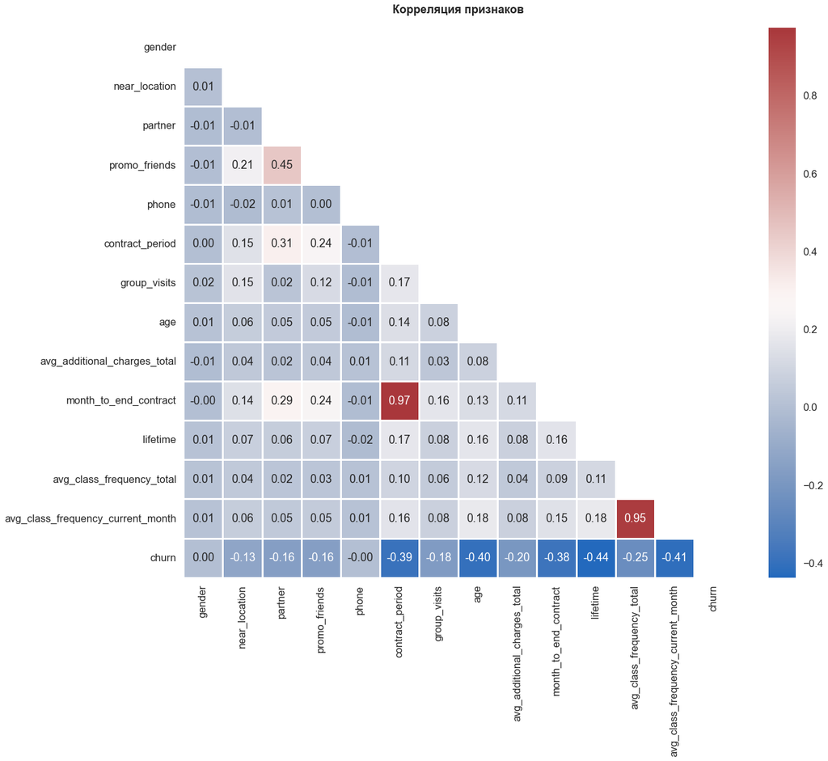

```python
plt.figure(figsize=(20,16))
sns.set(font_scale=1.5)
plt.style.use('seaborn-white')
plt.title('Корреляция признаков', fontweight='bold', y=1.02)
sns.heatmap(data=corr_m, square=True, annot=True, fmt=".2f", cmap='vlag', linewidths=3,
            linecolor='white', mask=np.triu(corr_m))
plt.show();
```

**Вывод**:

На графике матрицы корреляций мы видим, что в данных есть 2 пары сильно коррелирующих признаков:

- средняя частота посещений в неделю за всё время и за предыдущий месяц (0.95)
- длительность текущего абонемента и срок до его окончания (0.97)

Они могут помешать корректной работе моделей машинного обучения.

### Вывод

Из 4000 клиентов 2939 человек остались, а 1061 ушли в отток в текущем месяце.

Среди признаков есть такие, средние значения которых в двух группах **отличаются незначительно**: например,и ушедшие, и оставшиеся клиенты - люди обоих полов, и все они охотно оставляют свои номера телефонов. Ушедшие клиенты не так часто проживали или работали в районе фитнес-центров (по сравнению с оставшимися). Ушедшие клиенты в среднем чуть моложе: 27 лет против 30 у оставшихся.

В остальных признаках мы видим **заметные отличия** клиентов. Ушедшие клиенты реже появлялись в заведениях сети, для них характерна более низкая суммарная выручка от других услуг фитнес-центров, и они реже являлись сотрудниками компании-партнёра клуба. Ушедшие пользователи реже посещали групповые занятия, реже получали и использовали промокод от знакомых и друзей. Ушедшие клиенты и реже посещали зал (в среднем 1 раз в неделю) перед моментом своего "ухода". Такие пользователи имели небольшой срок до его окончания абонемента (около 1.5 месяцев) и в основном приобретали абонементы с небольшой длительностью (в среднем всего около 1.5-2 месяцев). Ушедшие в отток ненадолго задержались в статусе клиентов - средний лайфтайм ушедших чуть меньше 1 месяца.

С учётом распределения признаков, сравнения средних значений и построения матрицы кореляций мы можем прийти к выводу, что **наибольшее значение для оттока клиентов имеют следующие признаки**:

- возраст клиента
- средняя частота посещений в неделю за предыдущий месяц
- длительность текущего абонемента
- срок до окончания текущего абонемента
- лайфтайм

## Модель прогнозирования оттока клиентов

Поскольку у нас есть значения целевого признака, то мы можем провести так называемое "обучение с учителем". Поскольку у нас два варианта ответов, то мы будем делать бинарную классификацию.

Для начала разделим данные на признаки (матрица Х) и целевую переменную (y), убрав при этом по одному столбцу из каждой пары сильно коррелирующих признаков:

```python
X = df.drop(['churn', 'avg_class_frequency_current_month', 'month_to_end_contract'], axis=1)
y = df['churn']
```

Теперь разобьём наши данные на обучающую и валидационную выборки:

```python
X_train, X_test, y_train, y_test = train_test_split(X, y, test_size=0.2, random_state=0)
```

Создадим объект класса StandardScaler и применим его к обучающей выборке:

```python
scaler = StandardScaler()
X_train_st = scaler.fit_transform(X_train)
```

Применяем стандартизацию к матрице признаков для тестовой выборки:

```python
X_test_st = scaler.transform(X_test)
```

Задаём список моделей:

```python
models = [
    LogisticRegression(random_state=0),
    RandomForestClassifier(random_state=0)
]
```

Напишем функцию, которая принимает на вход модель и данные и выводит метрики:

```python
def make_prediction(m, X_train, y_train, X_test, y_test):
    model = m
    model.fit(X_train, y_train)
    y_pred = model.predict(X_test)
    print(
        'Accuracy:{:.2f} Precision:{:.2f} Recall:{:.2f} '.format(
            accuracy_score(y_test, y_pred),
            precision_score(y_test, y_pred),
            recall_score(y_test, y_pred)
        )
    )
```

Напишем цикл, который выводит метрики по списку моделей:

```python
for i in models:
    print(i)
    make_prediction(m=i, X_train=X_train_st, y_train=y_train,
                    X_test=X_test_st, y_test=y_test)
```

```
LogisticRegression(random_state=0)
Accuracy:0.90 Precision:0.79 Recall:0.81
RandomForestClassifier(random_state=0)
Accuracy:0.89 Precision:0.79 Recall:0.76
```

Посмотрим на "веса" при признаках:

```python
features = X.columns

s1=pd.Series(features)
s2=pd.DataFrame(models[0].coef_).T
s3=pd.Series(models[1].feature_importances_)
weight_features = pd.concat([s1,s2,s3], axis=1)
weight_features.columns=['features', 'model_1', 'model_2']
weight_features
```

|  | features | model_1 | model_2 |
| --- | --- | --- | --- |
| 0 | gender | 0.049457 | 0.017353 |
| 1 | near_location | -0.088120 | 0.013489 |
| 2 | partner | -0.053055 | 0.017395 |
| 3 | promo_friends | -0.217953 | 0.017572 |
| 4 | phone | -0.120001 | 0.009955 |
| 5 | contract_period | -1.316552 | 0.113528 |
| 6 | group_visits | -0.359770 | 0.022918 |
| 7 | age | -1.093218 | 0.145872 |
| 8 | avg_additional_charges_total | -0.567072 | 0.137607 |
| 9 | lifetime | -3.879688 | 0.336627 |
| 10 | avg_class_frequency_total | -0.730469 | 0.167682 |

### Вывод

Модели работают по-разному и рассчитывают различные "веса" для признаков.

Для первой модели (логистическая регрессия) важнейшими признаками являются:

- лайфтайм
- длительность текущего абонемента
- возраст
- частота посещений за всё время
- суммарная выручка от других услуг

Для второй модели (случайный лес):

- лайфтайм
- частота посещений за всё время
- возраст
- суммарная выручка от других услуг
- длительность текущего абонемента

Из двух обученных моделей первая - **логистическая регрессия** - имеет лучшие показатели метрик accuracy и recall, поэтому **признаем её лучшим вариантом**.

Метрика Recall говорит о том, что первая модель будет чаще находить клиентов, которые в ближайшем будущем могут уйти в отток. Если стратегия наших действий не будет включать критических затрат, то нам лучше перестраховаться, предложив потенциально уходящему клиенту какую-то небольшую скидку или бонус, чтобы удержать его. Поэтому нам лучше использовать модель с более высоким показателем Recall, и это первая модель.

Поскольку мы выбираем первую модель, то сосредочимся на важности признаков в том порядке, в каком их рассчитывает логистическая регрессия.

## Кластеризация клиентов

Теперь перейдём к следующей задаче: кластеризации клиентов. Для этого сначала стандартизируем данные:

```python
scaler = StandardScaler()
x_sc = scaler.fit_transform(X)
```

Построим матрицу расстояний на стандартизованной матрице признаков:

```python
linked = linkage(x_sc, method='ward')
```

### Дендрограмма

Теперь создадим дендрограмму:

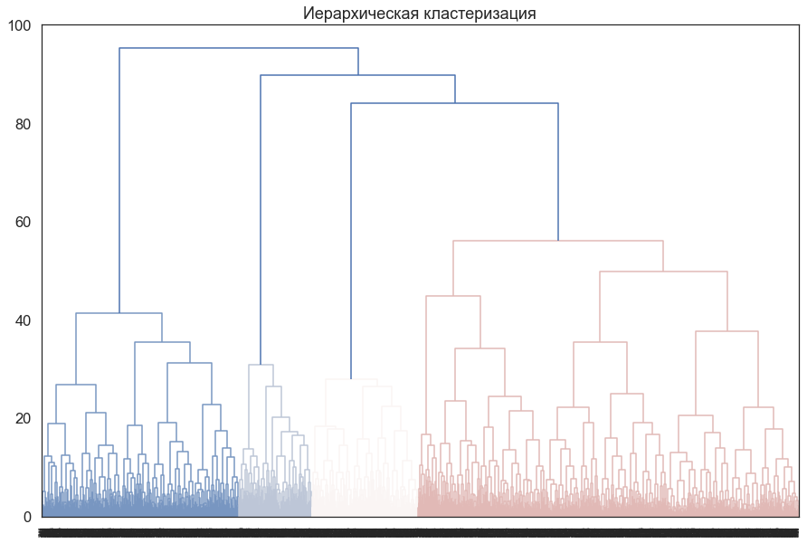

```python
plt.figure(figsize=(15,10))
hierarchy.set_link_color_palette(['#7896c1', '#bdc6d7', '#faf5f4', '#e1b9b6', '#c67875'])
dendrogram(linked, orientation='top')
plt.title('Иерархическая кластеризация')
plt.show()
```

Примем число кластеров, равное 5.

Обучим модель кластеризации на основании алгоритма K-Means и спрогнозируем кластеры клиентов:

```python
km = KMeans(n_clusters=5, random_state=0)
labels = km.fit_predict(x_sc)
```

Сохраняем метки кластера в поле нашего датасета:

```python
df['cluster_km'] = labels
```

### Средние значения признаков по кластерам

Рассчитаем статистику по средним значениям признаков в каждом кластере:

(Примечание: автоматически у нас кластеры нумеруются от 0, как индексы, но для удобства понимания мы обозначим их как кластеры под номерами 1, 2, 3, 4, 5)

```python
cluster_mean = df.groupby(['cluster_km']).mean().T.reset_index().rename_axis(None, axis=1)
cluster_mean.columns = ['features', 'cluster_1', 'cluster_2', 'cluster_3', 'cluster_4', 'cluster_5']
cluster_mean = (cluster_mean.merge(table, how='left', on='features').sort_values(by='coef', ascending=False)
                .drop('coef', axis=1).reset_index(drop=True))
cluster_mean
```

|  | features | cluster_1 | cluster_2 | cluster_3 | cluster_4 | cluster_5 | stay_mean | leave_mean |
| --- | --- | --- | --- | --- | --- | --- | --- | --- |
| 0 | gender | 0.499109 | 0.488571 | 0.505300 | 0.544202 | 0.523316 | 0.51 | 0.51 |
| 1 | phone | 1.000000 | 1.000000 | 1.000000 | 1.000000 | 0.000000 | 0.90 | 0.90 |
| 2 | age | 28.721925 | 29.543810 | 28.770318 | 29.536165 | 29.297927 | 29.98 | 26.99 |
| 3 | near_location | 0.000000 | 0.995238 | 1.000000 | 1.000000 | 0.862694 | 0.87 | 0.77 |
| 4 | avg_class_frequency_total | 1.770413 | 1.978963 | 1.800647 | 1.941342 | 1.854211 | 2.02 | 1.47 |
| 5 | avg_additional_charges_total | 137.540009 | 155.861428 | 143.383993 | 148.088897 | 144.208179 | 158.45 | 115.08 |
| 6 | partner | 0.488414 | 0.955238 | 0.238516 | 0.250287 | 0.471503 | 0.53 | 0.36 |
| 7 | group_visits | 0.235294 | 0.458095 | 0.000000 | 1.000000 | 0.427461 | 0.46 | 0.27 |
| 8 | promo_friends | 0.076649 | 0.892381 | 0.059187 | 0.079219 | 0.305699 | 0.35 | 0.18 |
| 9 | avg_class_frequency_current_month | 1.606619 | 1.933736 | 1.645965 | 1.845911 | 1.723967 | 2.03 | 1.04 |
| 10 | month_to_end_contract | 2.853832 | 6.988571 | 2.650177 | 4.165327 | 4.466321 | 5.28 | 1.66 |
| 11 | contract_period | 3.032086 | 7.660952 | 2.819788 | 4.528129 | 4.777202 | 5.75 | 1.73 |
| 12 | lifetime | 3.060606 | 4.380952 | 3.343640 | 3.761194 | 3.940415 | 4.71 | 0.99 |
| 13 | churn | 0.399287 | 0.120952 | 0.381625 | 0.200918 | 0.266839 | NaN | NaN |

Визуализируем наши данные:

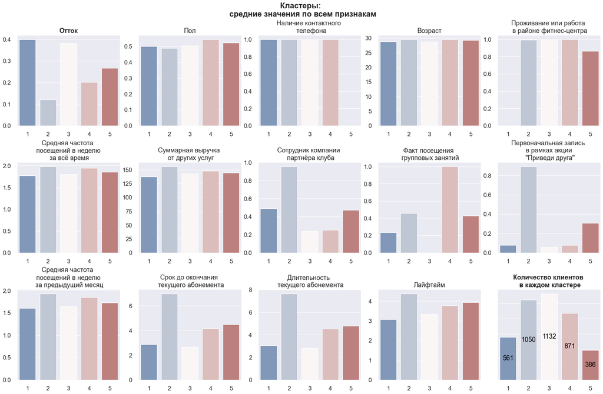

```python
fig = plt.figure(constrained_layout=True, figsize=(23, 15))
sns.set(font_scale=1.5)
plt.style.use('fast')
plt.suptitle('Кластеры: \n средние значения по всем признакам', fontweight='bold')

spec = gridspec.GridSpec(ncols=5, nrows=3, figure=fig)

ax0 = fig.add_subplot(spec[0, 0])
sns.barplot(data= cluster_mean.iloc[13],  x=['1', '2', '3', '4', '5'],
            y=['cluster_1', 'cluster_2', 'cluster_3', 'cluster_4', 'cluster_5'], palette = 'vlag')
plt.title('Отток', fontweight='bold')
plt.xlabel('')
plt.ylabel('')

ax1 = fig.add_subplot(spec[0, 1])
sns.barplot(data= cluster_mean.iloc[0], x=['1', '2', '3', '4', '5'],
            y=['cluster_1', 'cluster_2', 'cluster_3', 'cluster_4', 'cluster_5'], palette = 'vlag')
plt.title('Пол')
plt.xlabel('')
plt.ylabel('')

ax2 = fig.add_subplot(spec[0, 2])
sns.barplot(data= cluster_mean.iloc[1], x=['1', '2', '3', '4', '5'],
            y=['cluster_1', 'cluster_2', 'cluster_3', 'cluster_4', 'cluster_5'], palette = 'vlag')
plt.title('Наличие контактного \n  телефона')
plt.xlabel('')
plt.ylabel('')

ax3 = fig.add_subplot(spec[0, 3])
sns.barplot(data= cluster_mean.iloc[2], x=['1', '2', '3', '4', '5'],
            y=['cluster_1', 'cluster_2', 'cluster_3', 'cluster_4', 'cluster_5'], palette = 'vlag')
plt.title('Возраст')
plt.xlabel('')
plt.ylabel('')

ax4 = fig.add_subplot(spec[0, 4])
sns.barplot(data= cluster_mean.iloc[3], x=['1', '2', '3', '4', '5'],
            y=['cluster_1', 'cluster_2', 'cluster_3', 'cluster_4', 'cluster_5'], palette = 'vlag')
plt.title('Проживание или работа \n в районе фитнес-центра')
plt.xlabel('')
plt.ylabel('')

ax5 = fig.add_subplot(spec[1, 0])
sns.barplot(data= cluster_mean.iloc[4], x=['1', '2', '3', '4', '5'],
            y=['cluster_1', 'cluster_2', 'cluster_3', 'cluster_4', 'cluster_5'], palette = 'vlag')
plt.title('Средняя частота \n посещений в неделю \n за всё время')
plt.xlabel('')
plt.ylabel('')

ax6 = fig.add_subplot(spec[1, 1])
sns.barplot(data= cluster_mean.iloc[5], x=['1', '2', '3', '4', '5'],
            y=['cluster_1', 'cluster_2', 'cluster_3', 'cluster_4', 'cluster_5'], palette = 'vlag')
plt.title('Суммарная выручка \n от других услуг')
plt.xlabel('')
plt.ylabel('')

ax7 = fig.add_subplot(spec[1, 2])
sns.barplot(data= cluster_mean.iloc[6], x=['1', '2', '3', '4', '5'],
            y=['cluster_1', 'cluster_2', 'cluster_3', 'cluster_4', 'cluster_5'], palette = 'vlag')
plt.title('Сотрудник компании \n партнёра клуба')
plt.xlabel('')
plt.ylabel('')

ax8 = fig.add_subplot(spec[1, 3])
sns.barplot(data= cluster_mean.iloc[7], x=['1', '2', '3', '4', '5'],
            y=['cluster_1', 'cluster_2', 'cluster_3', 'cluster_4', 'cluster_5'], palette = 'vlag')
plt.title('Факт посещения \n групповых занятий')
plt.xlabel('')
plt.ylabel('')

ax9 = fig.add_subplot(spec[1, 4])
sns.barplot(data= cluster_mean.iloc[8], x=['1', '2', '3', '4', '5'],
            y=['cluster_1', 'cluster_2', 'cluster_3', 'cluster_4', 'cluster_5'], palette = 'vlag')
plt.title('Первоначальная запись \n в рамках акции \n "Приведи друга"')
plt.xlabel('')
plt.ylabel('')

ax10 = fig.add_subplot(spec[2, 0])
sns.barplot(data= cluster_mean.iloc[9], x=['1', '2', '3', '4', '5'],
            y=['cluster_1', 'cluster_2', 'cluster_3', 'cluster_4', 'cluster_5'], palette = 'vlag')
plt.title('Средняя частота \n посещений в неделю \n за предыдущий месяц')
plt.xlabel('')
plt.ylabel('')

ax11 = fig.add_subplot(spec[2, 1])
sns.barplot(data= cluster_mean.iloc[10], x=['1', '2', '3', '4', '5'],
            y=['cluster_1', 'cluster_2', 'cluster_3', 'cluster_4', 'cluster_5'], palette = 'vlag')
plt.title('Срок до окончания \n текущего абонемента')
plt.xlabel('')
plt.ylabel('')

ax12 = fig.add_subplot(spec[2, 2])
sns.barplot(data= cluster_mean.iloc[11], x=['1', '2', '3', '4', '5'],
            y=['cluster_1', 'cluster_2', 'cluster_3', 'cluster_4', 'cluster_5'], palette = 'vlag')
plt.title('Длительность \n текущего абонемента')
plt.xlabel('')
plt.ylabel('')

ax13 = fig.add_subplot(spec[2, 3])
sns.barplot(data= cluster_mean.iloc[12], x=['1', '2', '3', '4', '5'],
            y=['cluster_1', 'cluster_2', 'cluster_3', 'cluster_4', 'cluster_5'], palette = 'vlag')
plt.title('Лайфтайм')
plt.xlabel('')
plt.ylabel('')

ax14 = fig.add_subplot(spec[2, 4])
cluster_cnt = df.groupby('cluster_km').agg({'phone':'count'})
cluster_cnt = cluster_cnt['phone']
sns.barplot(x=['1','2','3','4','5'],
            y=cluster_cnt, palette = 'vlag')
plt.title('Количество клиентов \n в каждом кластере', fontweight='bold')
plt.xlabel('')
plt.ylabel('')
ax14.set(yticklabels=[])
ax14.tick_params(left=False)
ax14.bar_label(ax14.containers[0], label_type='center', color='black')

plt.show();
```

**Вывод**:

- если мы первым делом посмотрим на уровень оттока, то мы сразу поймём, что **нам стоит приглядеться к кластерам 1 и 3**, так как они имеют самые большие уровни оттока клиентов. Условно разделим наши кластеры на "устойчивых" и "требующих внимания" клиентов.

Что же характерно для "требующих внимания" клиентов?

Рассмотрим подробнее **кластер 1**:

- они не проживают или работают в районе фитнес-центра
- в среднем чуть реже других ходят на тренировки
- тратят меньше денег на смежные услуги
- около половины из них являются сотрудниками компании-партнёра клуба
- такие клиенты редко ходят на групповые занятия и очень редко используют промокод от друга при оплате первого абонемента
- такие клиенты берут не долгий срок абонемента (в среднем 3 месяца) и не задерживаются с нами надолго (лайфтайм в среднем 3 месяца)

Теперь рассмотрим **кластер 3**:

- они также чуть реже других посещают тренировки и тратят меньше денег на прочие услуги
- такие клиенты редко являются сотрудниками компании-партнёра и редко используют промокод от друга
- ключевое отличие: эти клиенты совсем не посещают групповые занятия
- также их роднят с клиентами 1-го кластера короткие сроки абонементов (в среднем 3 месяца) и низкий лайфтайм (в среднем около 3.5 месяцев)

При этом отметим количество клиентов в кластерах: если в 1-м у нас чуть более 500 человек, то в третьем - в 2 раза больше клиентов.

### Распределения признаков для кластеров

Теперь подготовим данные и визуализируем уже не среднее, а распределение данных во всех кластерах:

```python
df_words['cluster_km'] = labels
```

```python
cluster_1 = df_words.query('cluster_km ==0')
cluster_2 = df_words.query('cluster_km ==1')
cluster_3 = df_words.query('cluster_km ==2')
cluster_4 = df_words.query('cluster_km ==3')
cluster_5 = df_words.query('cluster_km ==4')
```

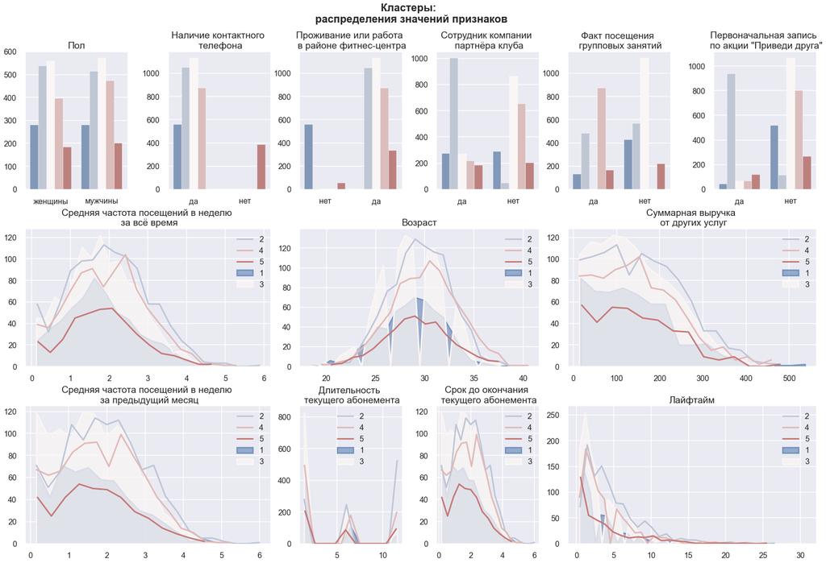

```python
fig = plt.figure(constrained_layout=True, figsize=(23, 15))
sns.set(font_scale=1.5)
plt.style.use('seaborn-poster')
plt.suptitle('Кластеры: \n распределения значений признаков', fontweight='bold', y=1.05)

spec = gridspec.GridSpec(ncols=6, nrows=3, figure=fig)

ax0 = fig.add_subplot(spec[0, 0])
data = df_words.groupby(['cluster_km', 'gender'], as_index=False).agg({'phone':'count'})
sns.barplot(data=data, x='gender', y='phone', hue ='cluster_km', palette = 'vlag')
plt.title('Пол')
plt.xlabel('')
plt.ylabel('')
ax0.get_legend().remove()

ax1 = fig.add_subplot(spec[0, 1])
data = df_words.groupby(['cluster_km', 'phone'], as_index=False).agg({'gender':'count'})
sns.barplot(data=data, x='phone', y='gender', hue ='cluster_km', palette = 'vlag')
plt.title('Наличие контактного \n телефона')
plt.xlabel('')
plt.ylabel('')
ax1.get_legend().remove()

ax2 = fig.add_subplot(spec[0, 2])
data = df_words.groupby(['cluster_km', 'near_location'], as_index=False).agg({'phone':'count'})
sns.barplot(data=data, x='near_location', y='phone', hue ='cluster_km', palette = 'vlag')
plt.title('Проживание или работа \n в районе фитнес-центра')
plt.xlabel('')
plt.ylabel('')
ax2.get_legend().remove()

ax3 = fig.add_subplot(spec[0, 3])
data = df_words.groupby(['cluster_km', 'partner'], as_index=False).agg({'phone':'count'})
sns.barplot(data=data, x='partner', y='phone', hue ='cluster_km', palette = 'vlag')
plt.title('Сотрудник компании \n партнёра клуба')
plt.xlabel('')
plt.ylabel('')
ax3.get_legend().remove()

ax4 = fig.add_subplot(spec[0, 4])
data = df_words.groupby(['cluster_km', 'group_visits'], as_index=False).agg({'phone':'count'})
sns.barplot(data=data, x='group_visits', y='phone', hue ='cluster_km', palette = 'vlag')
plt.title('Факт посещения \n групповых занятий')
plt.xlabel('')
plt.ylabel('')
ax4.get_legend().remove()

ax5 = fig.add_subplot(spec[0, 5])
data = df_words.groupby(['cluster_km', 'promo_friends'], as_index=False).agg({'phone':'count'})
sns.barplot(data=data, x='promo_friends', y='phone', hue ='cluster_km', palette = 'vlag')
plt.title('Первоначальная запись \n по акции "Приведи друга"')
plt.xlabel('')
plt.ylabel('')
ax5.get_legend().remove()

ax6 = fig.add_subplot(spec[1, :-4])
sns.histplot(data=cluster_1, x='avg_class_frequency_total', color='#7896c1', element="poly", linewidth=3, label='1')
sns.histplot(data=cluster_2, x='avg_class_frequency_total', color='#bdc6d7', element="poly", fill=False, linewidth=3, label='2')
sns.histplot(data=cluster_3, x='avg_class_frequency_total', color='#faf5f4', element="poly", linewidth=3, label='3')
sns.histplot(data=cluster_4, x='avg_class_frequency_total', color='#e1b9b6', element="poly", fill=False, linewidth=3, label='4')
sns.histplot(data=cluster_5, x='avg_class_frequency_total', color='#c67875', element="poly", fill=False, linewidth=3, label='5')
plt.title('Средняя частота посещений в неделю \n за всё время')
plt.xlabel('')
plt.ylabel('')
plt.legend()

ax7 = fig.add_subplot(spec[1, -4:-2])
sns.histplot(data=cluster_1, x='age', color='#7896c1', element="poly", linewidth=3, label='1')
sns.histplot(data=cluster_2, x='age', color='#bdc6d7', element="poly", fill=False, linewidth=3, label='2')
sns.histplot(data=cluster_3, x='age', color='#faf5f4', element="poly", linewidth=3, label='3')
sns.histplot(data=cluster_4, x='age', color='#e1b9b6', element="poly", fill=False, linewidth=3, label='4')
sns.histplot(data=cluster_5, x='age', color='#c67875', element="poly", fill=False, linewidth=3, label='5')
plt.title('Возраст')
plt.xlabel('')
plt.ylabel('')
plt.legend()

ax8 = fig.add_subplot(spec[1, -2:])
sns.histplot(data=cluster_1, x='avg_additional_charges_total', color='#7896c1', element="poly", linewidth=3, label='1')
sns.histplot(data=cluster_2, x='avg_additional_charges_total', color='#bdc6d7', element="poly", fill=False, linewidth=3, label='2')
sns.histplot(data=cluster_3, x='avg_additional_charges_total', color='#faf5f4', element="poly", linewidth=3, label='3')
sns.histplot(data=cluster_4, x='avg_additional_charges_total', color='#e1b9b6', element="poly", fill=False, linewidth=3, label='4')
sns.histplot(data=cluster_5, x='avg_additional_charges_total', color='#c67875', element="poly", fill=False, linewidth=3, label='5')
plt.title('Суммарная выручка \n от других услуг')
plt.xlabel('')
plt.ylabel('')
plt.legend()

ax9 = fig.add_subplot(spec[2, :-4])
sns.histplot(data=cluster_1, x='avg_class_frequency_current_month', color='#7896c1', element="poly", linewidth=3, label='1')
sns.histplot(data=cluster_2, x='avg_class_frequency_current_month', color='#bdc6d7', element="poly", fill=False, linewidth=3, label='2')
sns.histplot(data=cluster_3, x='avg_class_frequency_current_month', color='#faf5f4', element="poly", linewidth=3, label='3')
sns.histplot(data=cluster_4, x='avg_class_frequency_current_month', color='#e1b9b6', element="poly", fill=False, linewidth=3, label='4')
sns.histplot(data=cluster_5, x='avg_class_frequency_current_month', color='#c67875', element="poly", fill=False, linewidth=3, label='5')
plt.title('Средняя частота посещений в неделю \n за предыдущий месяц')
plt.xlabel('')
plt.ylabel('')
plt.legend()

ax10 = fig.add_subplot(spec[2, -4])
sns.histplot(data=cluster_1, x='contract_period', color='#7896c1', element="poly",  linewidth=3, label='1')
sns.histplot(data=cluster_2, x='contract_period', color='#bdc6d7', element="poly", fill=False, linewidth=3, label='2')
sns.histplot(data=cluster_3, x='contract_period', color='#faf5f4', element="poly", linewidth=3, label='3')
sns.histplot(data=cluster_4, x='contract_period', color='#e1b9b6', element="poly", fill=False, linewidth=3, label='4')
sns.histplot(data=cluster_5, x='contract_period', color='#c67875', element="poly", fill=False, linewidth=3, label='5')
plt.title('Длительность \n текущего абонемента')
plt.xlabel('')
plt.ylabel('')
plt.legend()

ax11 = fig.add_subplot(spec[2, -3])
sns.histplot(data=cluster_1, x='avg_class_frequency_current_month', color='#7896c1', element="poly", linewidth=3, label='1')
sns.histplot(data=cluster_2, x='avg_class_frequency_current_month', color='#bdc6d7', element="poly", fill=False, linewidth=3, label='2')
sns.histplot(data=cluster_3, x='avg_class_frequency_current_month', color='#faf5f4', element="poly", linewidth=3, label='3')
sns.histplot(data=cluster_4, x='avg_class_frequency_current_month', color='#e1b9b6', element="poly", fill=False, linewidth=3, label='4')
sns.histplot(data=cluster_5, x='avg_class_frequency_current_month', color='#c67875', element="poly", fill=False, linewidth=3, label='5')
plt.title('Срок до окончания \n текущего абонемента')
plt.xlabel('')
plt.ylabel('')
plt.legend()

ax12 = fig.add_subplot(spec[2, -2:])
sns.histplot(data=cluster_1, x='lifetime', color='#7896c1', element="poly",  linewidth=3, label='1')
sns.histplot(data=cluster_2, x='lifetime', color='#bdc6d7', element="poly", fill=False, linewidth=3, label='2')
sns.histplot(data=cluster_3, x='lifetime', color='#faf5f4', element="poly", linewidth=3, label='3')
sns.histplot(data=cluster_4, x='lifetime', color='#e1b9b6', element="poly", fill=False, linewidth=3, label='4')
sns.histplot(data=cluster_5, x='lifetime', color='#c67875', element="poly", fill=False, linewidth=3, label='5')
plt.title('Лайфтайм')
plt.xlabel('')
plt.ylabel('')
plt.legend()

plt.show();
```

**Вывод**:

на основе этих и предыдущих данных попробуем составить условные портреты клиентов из всех наших пяти кластеров:

**1. "Не местный"**: главная отличительная черта клиентов этого кластера - они проживают и работают вне района, где расположен фитнес-центр. Видимо, из-за этого неудобства они и реже посещеют зал (в среднем не более 2 раз в неделю) и не берут "долгих" абонементов. Такие клиенты редко посещают групповые занятия и почти не используют промокод от друга при оплате первого абонемента. Определённый интерес у этих клиентов, видимо, связан с тем, что около половины таких клиентов - это сотрудники компании-партнёра клуба. Однако из-за географического неудобства они редко остаются с нами надолго (лайфтайм редко превышает год).

**2. "Друг/партнёр"**: сотрудники компании-партнёра, которые проживают или работают в районе фитнес-центра, показывают совсем другие результаты: это одни из самых надёжных клиентов (у этой группы минимальный отток и самый высокий лайфтайм). Такие клиенты тренируются в среднем чуть чаще других (около 2 раз в неделю), а некоторые и вовсе готовы приходить в зал чуть ли не каждый день. От этих людей фитнес-центры получают чуть более высокую среднюю выручку по другим услугам. Именно эти клиенты часто покупают самые продолжительные абонементы на год. Эта группа клиентов в большинстве своём - сотрудники компании-партёра и/или клиенты, использовавшие промокод от друга при оплате первого абонемента, поэтому мы так и назовём этот кластер.

**3. "Индивидуалист"**: отличительная черта - такие клиенты не посещают групповых занятий. Этот кластер подвержен оттоку. Клиенты этого кластера, также как и клиенты 1-го кластера, в среднем чуть моложе остальных посетителей, и чуть реже посещают тренировки. Это самая многочисленная категория, поэтому важно снизить уровень оттока для этой группы. "Индивидуалисты" такие клиенты ещё и потому, что очень редко используют промокод от друга при оплате первого абонемента. В среднем представители этого кластера используют абонементы небольших сроков (около 3-х месяцев в среднем) и задерживаются в среднем тоже недолго (чуть более 3-х месяцев). Потенциальный плюс для этой группы - у них нет географических проблем: все они проживают или работают в районе фитнес-центра.

**4. "Любитель групповых занятий"**: отличительная черта клиентов этого кластера - приверженность к формату групповых занятий. Эти люди тренируются в среднем 2 раза в неделю, проживают или работают в районе фитнес-центра. Интересно, что впервые мы видим неравномерное распределение по половому признаку: здесь больше мужчин.

**5. "Абонент недоступен"**: последний кластер состоит из клиентов, не оставивших свой номер телефона. Эта группа клиентов самая немногочисленная. В каком-то смысле клиент из этого кластера - человек-загадка. Он не имеет особых специфических черт, кроме того, что пожелал скрыть свой номер телефона. При этом данный кластер имеет неплохие показатели по длине покупаемых абонементов и лайфтайму (второе место среди кластеров после группы 2 "друг/партнёр")

Предпологаю, что при ином количестве кластеров и/или другом расчёте (не зафиксированном random_state=0) кластеры могут сформироваться более информативно и показать нам другие черты пользователей и другие "портреты".

### Доля оттока для каждого кластера

Теперь рассчитаем доли оттока:

```python
churn_table = (df.groupby('cluster_km').agg({'phone':'count', 'churn':'sum'})
                                .rename(columns={'phone':'cnt_cluster', 'churn':'cnt_leave'}).reset_index(drop=True))
churn_table['perc_cluster'] = churn_table['cnt_cluster'] / len(df) *100
churn_table['perc_from_total'] = churn_table['cnt_leave'] / len(df.query('churn==1')) *100
churn_table['perc_from_cluster'] = churn_table['cnt_leave'] / churn_table['cnt_cluster'] *100
churn_table
```

|  | cnt_cluster | cnt_leave | perc_cluster | perc_from_total | perc_from_cluster |
| --- | --- | --- | --- | --- | --- |
| 0 | 561 | 224 | 14.025 | 21.112158 | 39.928699 |
| 1 | 1050 | 127 | 26.250 | 11.969840 | 12.095238 |
| 2 | 1132 | 432 | 28.300 | 40.716305 | 38.162544 |
| 3 | 871 | 175 | 21.775 | 16.493874 | 20.091848 |
| 4 | 386 | 103 | 9.650 | 9.707823 | 26.683938 |

И визуализируем степень "надёжности" наших кластеров:

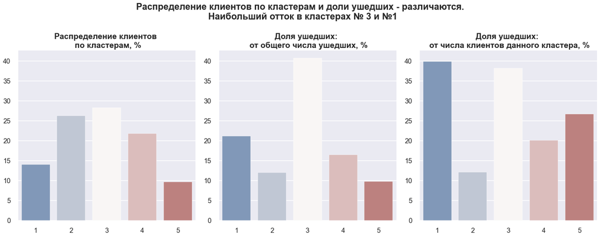

```python
plt.figure(figsize=(20, 8))
sns.set(font_scale=1.5)
plt.style.use('seaborn-poster')
plt.suptitle(
    'Распределение клиентов по кластерам и доли ушедших - различаются.\n  Наибольший отток в кластерах № 3 и №1',
             fontweight='bold')

ax1 = plt.subplot(1, 3, 1)
sns.barplot(x=['1','2','3','4','5'],
            y=churn_table['perc_cluster'], palette = 'vlag')
plt.title('Распределение клиентов \n по кластерам, %', fontweight='bold')
plt.xlabel('')
plt.ylabel('')

ax2 = plt.subplot(1, 3, 2, sharey=ax1)
sns.barplot(x=['1','2','3','4','5'],
            y=churn_table['perc_from_total'], palette = 'vlag')
plt.title('Доля ушедших: \n от общего числа ушедших, %', fontweight='bold')
plt.xlabel('')
plt.ylabel('')

ax3 = plt.subplot(1, 3, 3, sharey=ax1)
sns.barplot(x=['1','2','3','4','5'],
            y=churn_table['perc_from_cluster'], palette = 'vlag')
plt.title('Доля ушедших: \n от числа клиентов данного кластера, %', fontweight='bold')
plt.xlabel('')
plt.ylabel('')

plt.tight_layout()
plt.show();
```

**Вывод**:

- мы определили две условные большие группы наших клиентов: "устойчивые" (кластеры 2, 4, 5) и "требующие внимания" (кластеры 1 и 3) - они отличаются по долям оттока
- наибольшую проблему с точки зрения оттока представляют кластеры 3 и 1. В кластере 3 собрано около 40% всех клиентов, которые ушли в отток. А если посмотреть с точки зрения этого отдельно взятого кластера, то нам также нужно обратить внимание на кластер 1. Каждый 4-й из 10 пришедших в этот кластер уходит от нас в отток. Этой аудитории явно нужно что-то предложить и попытаться удержать их внимание.

## Выводы

На хорошо подготовленных предоставленных данных из 4000 строк и 14 столбцов был проведён **исследовательский анализ данных**. С учётом распределения признаков, сравнения средних значений и построения матрицы кореляций мы пришли к выводу, что наибольшее значение для оттока клиентов имеют следующие признаки:

- возраст клиента
- средняя частота посещений в неделю за предыдущий месяц
- длительность текущего абонемента
- срок до окончания текущего абонемента
- лайфтайм

С помощью машинного обучения были построены **модели прогнозирования оттока клиентов**. Из двух обученных моделей первая (логистическая регрессия) имеет лучшие показатели метрик accuracy и recall, поэтому мы признаём её лучшим вариантом.

С помощью **кластеризации** мы смогли выделить условные группы клиентов и дать им краткое описание:

**1. "Не местный"**: главная отличительная черта клиентов этого кластера - они проживают и работают вне района, где расположен фитнес-центр. Видимо, из-за этого неудобства они и реже посещеют зал (в среднем не более 2 раз в неделю) и не берут "долгих" абонементов. Такие клиенты редко посещают групповые занятия и почти не используют промокод от друга при оплате первого абонемента. Определённый интерес у этих клиентов, видимо, связан с тем, что около половины таких клиентов - это сотрудники компании-партнёра клуба. Однако из-за географического неудобства они редко остаются с нами надолго (лайфтайм редко превышает год).

**2. "Друг/партнёр"**: сотрудники компании-партнёра, которые проживают или работают в районе фитнес-центра, показывают совсем другие результаты: это одни из самых надёжных клиентов (у этой группы минимальный отток и самый высокий лайтайм). Такие клиенты тренируются в среднем чуть чаще других (около 2 раз в неделю), а некоторые и вовсе готовы приходить в зал чуть ли не каждый день. От этих людей фитнес-центры получают чуть более высокую среднюю выручку по другим услугам. Именно эти клиенты часто покупают самые продолжительные абонементы на год. Эта группа клиентов в большинстве своём - сотрудники компании-партёра и/или клиенты, использовавшие промокод от друга при оплате первого абонемента, поэтому мы так и назовём этот кластер.

**3. "Индивидуалист"**: отличительная черта - такие клиенты не посещают групповых занятий. Этот кластер подвержен оттоку. Клиенты этого кластера, также как и клиенты 1-го кластера, в среднем чуть моложе остальных посетителей, и чуть реже посещают тренировки. Это самая многочисленная категория, поэтому важно снизить уровень оттока для этой группы. "Индивидуалисты" такие клиенты ещё и потому, что очень редко используют промокод от друга при оплате первого абонемента. В среднем представители этого кластера используют абонементы небольших сроков (около 3-х месяцев в среднем) и задерживаются в среднем тоже недолго (чуть более 3-х месяцев). Потенциальный плюс для этой группы - у них нет географических проблем: все они проживают или работают в районе фитнес-центра.

**4. "Любитель групповых занятий"**: отличительная черта клиентов этого кластера - приверженность к формату групповых занятий. Эти люди тренируются в среднем 2 раза в неделю, проживают или работают в районе фитнес-центра. Интересно, что впервые мы видим неравномерное распределение по половому признаку: здесь больше мужчин.

**5. "Абонент недоступен"**: последний кластер состоит из клиентов, не оставивших свой номер телефона. Эта группа клиентов самая немногочисленная. В каком-то смысле клиент из этого кластера - человек-загадка. Он не имеет особых специфических черт, кроме того, что пожелал скрыть свой номер телефона. При этом данный кластер имеет неплохие показатели по длине покупаемых абонементов и лайфтайму (второе место среди кластеров после группы 2 "друг/партнёр")

- мы определили две условные большие группы наших клиентов: "устойчивые" (кластеры 2, 4, 5) и "требующие внимания" (кластеры 1 и 3) - они отличаются по долям оттока
- наибольшую проблему с точки зрения оттока представляют кластеры 3 и 1. Этой аудитории явно нужно что-то предложить и попытаться удержать их внимание.

**Главное, за чем нужно следить:**

**- лайфтайм**

**- длительность текущего абонемента**

**- возраст**

**Предложения**:

Нам надо стараться увеличивать лайфтайм новых пользователей, увеличивать длительность покупаемых абонементов, и делать привлекательные условия для более молодых клиентов. Как это можно сделать, ряд конкретных предложений - в зависимости от кластера клиента - привожу ниже:

для "индивидуалистов":

1. Предложить первое бесплатное пробное посещение группового занятия
2. Делать скидку на групповые занятия новым клиентам на первое время
3. Предлагать новым клиентам самим приводить друзей и получать за это бонус
4. Предложить новый вид абонемента, например, на 2 или 3 месяца (с тем чтобы это выгодно отличалось от покупки абонемента на 1 месяц)
5. Новому клиенту, который прошёл свой первый месяц занятий, предложить скидку на покупку более продолжительного абонемента или скидку на дополнительные услуги
6. Ввести внутриклубную накопительную систему баллов: если клиент стабильно занимается месяц-два-три, он понимает, что сможет рассчитывать продолжение абонемента на выгодных для него условиях
7. Запустить акцию: предложить клиенту, заполняя данные о себе, самому сформулировать конкретно-измеримую цель своих занятий и выбирать подходящий вид "приза" за достижение результата (скидка на смежные услуги, скидка на продление абонемента, одно бесплатное занятие, мерч от сети фитнес-центров). Это может повысить вовлечённость клиента и подстегнёт мотивацию к регулярным занятиям.

для решения проблемы "не-местых" клиентов:

1. Для тех клиентов, кто проживает и работает не в районе фитнес-центра, подсказывать, есть ли заведение нашей сети ближе к их району; при возможности, просчитать перспективы открытия филиала ещё в каком-то районе города
2. Привлечь ещё компанию-партнёра (возможно, офис которой находится недалеко от одного из фитнес-центров сети)

Для всех кластеров:

1. Делать специальные условия для студентов

Исследование выполнила: аналитик данных Малахова Наталья

Мой телеграм-канал: [Дневник аналитика](https://t.me/diary_musician_analyst)

Портфолио: [GitHub](https://github.com/Malakhova-Natalya)

Спасибо за внимание!